# Praktikum 04 - MPDW

Rani Yasmin Azzahra G1401211100

2023-09-21

# Proses MA

## White Noise

Pembangkitan data berpola AR, MA, ARMA, dan banyak proses deret waktu lainnya diawali pembangkitan *white noise*. *White noise* merupakan sederet nilai dari peubah bebas stokastik identik. Oleh karena itu, *white noise* memiliki dua karakteristik penting:

1. *White noise* tidak memiliki autokorelasi (**karena saling bebas**)
2. Nilai harapan dan ragam *white noise* sama (**karena berasal dari peubah acak bebas stokastik identik**)

*White noise* dibangkitkan dari suatu peubah acak, umumnya peubah acak normal.

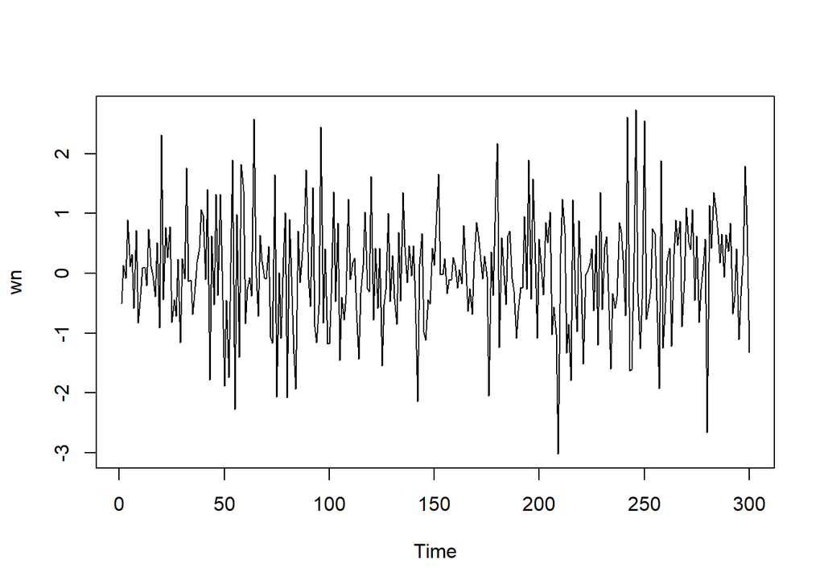

```r
set.seed(100)
wn <- rnorm(300)
ts.plot(wn)
```

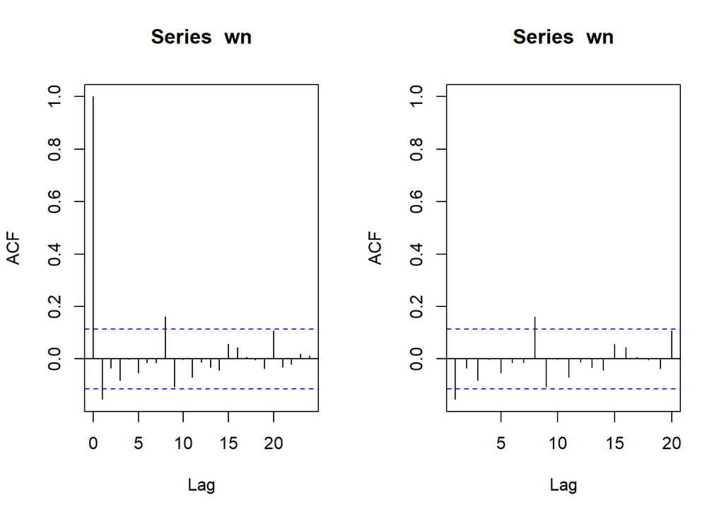

```r
par(mfrow = c(1, 2))
acf(wn)
acf(wn, xlim = c(1, 20))
```

Dapat terlihat bahwa *white noise* tidak memiliki autokorelasi dari ACF. Perhatikan bahwa lag ke-0 adalah korelasi observasi ke-t dengan dirinya sendiri. Nilai korelasi tersebut pasti 1. Sebagai alternatif, lag pertama di plot ACF dapat ditetapkan sebagai 1 (alih-alih 0) dengan menambahkan argumen `xlim(1, lag akhir)`. Plot tersebut dapat disandingkan bersamaan dengan membuat matriks $1 \times 2$ dengan `par(mfrow = c(1,2))`.

## Proses MA

Proses MA dapat dituliskan sebagai berikut:

$$y_{t} = c + e_t + \theta_{1}e_{t-1} + \theta_{2}e_{t-2} + \dots +
\theta_{q}e_{t-q} = c+{e_t+\sum_{i=1}^p \theta_ie_{t-i}}$$
Terlihat bahwa $e_t$, atau *white noise*, berperan penting dalam pembangkitan proses MA.

## Pembangkitan Proses MA(2)

```r
set.seed(100)
ma <- wn[1]
```

Nilai-nilai selanjutnya dapat dicari melalui *loop*. Bentuk loop dapat dilihat dari rumus MA(2) yang hendak dibangkitkan:

$$y_t = e_t+0.4e_{t-1}+0.6e_{t-2}$$

```r
for(i in 3:300){
   ma[i] <- wn[i] + 0.4 * wn[i - 1] + 0.6 * wn[i - 2]
}
ma
```

```
##   [1] -0.5021923505            NA -0.3276200340  0.9341366727  0.4243349404
##   [6]  0.8974894815 -0.3841558874  0.6729944896 -0.8885207523 -0.2612462752
##  [11] -0.5492143643 -0.0836883610 -0.1091924818  0.7169515952  0.2983353297
##  [16]  0.4639393911 -0.3265532299  0.3377245331 -0.9427842306  2.2512849031
##  [21] -0.0622597632  1.9750027176  0.3047315493  1.3366254832 -0.3478405113
##  [26] -0.3001594610 -1.3842292528 -0.3202144293 -1.4974845796 -0.0774490729
##  [31] -0.6869208418  1.8691757931  0.5103525002  0.8880600332 -0.8172494857
##  [36] -0.5645160554 -0.3198186008  0.3574098217  1.3420762517  1.6467569199
##  [41]  0.9256929647  1.9446730036 -1.2764717799  0.7540792312 -1.3392017743
##  [46]  1.4870380498 -0.1479179553  1.9670281852  0.3533411686 -1.0697048094
##  [51] -1.1722570942 -3.0446163492 -0.7848116395  0.9258528713 -1.4056202968
##  [56]  1.2101733644 -2.3697952524  1.8536206597  1.2719523293  0.8085910707
##  [61]  0.2312427134 -0.6769534628 -0.5636186324  2.3890990883  0.9352875745
##  [66]  0.8880840314  0.4306847332  0.0290743007  0.3935562342  0.0005583003
##  [71]  0.3699571540 -0.9402882867 -1.3188196266  0.5449406154 -2.1001389139
```

[output cut: 45 more lines]

```r
ma2 <- arima.sim(list(order=c(0,0,2), ma=c(0.4,0.6)), n=300)
ma2
```

```
## Time Series:
## Start = 1
## End = 300
## Frequency = 1
##   [1] -0.3276200340  0.9341366727  0.4243349404  0.8974894815 -0.3841558874
##   [6]  0.6729944896 -0.8885207523 -0.2612462752 -0.5492143643 -0.0836883610
##  [11] -0.1091924818  0.7169515952  0.2983353297  0.4639393911 -0.3265532299
##  [16]  0.3377245331 -0.9427842306  2.2512849031 -0.0622597632  1.9750027176
##  [21]  0.3047315493  1.3366254832 -0.3478405113 -0.3001594610 -1.3842292528
##  [26] -0.3202144293 -1.4974845796 -0.0774490729 -0.6869208418  1.8691757931
##  [31]  0.5103525002  0.8880600332 -0.8172494857 -0.5645160554 -0.3198186008
##  [36]  0.3574098217  1.3420762517  1.6467569199  0.9256929647  1.9446730036
##  [41] -1.2764717799  0.7540792312 -1.3392017743  1.4870380498 -0.1479179553
##  [46]  1.9670281852  0.3533411686 -1.0697048094 -1.1722570942 -3.0446163492
##  [51] -0.7848116395  0.9258528713 -1.4056202968  1.2101733644 -2.3697952524
```

[output cut: 49 more lines]

## Karakteristik MA(2)

### Plot Time Series

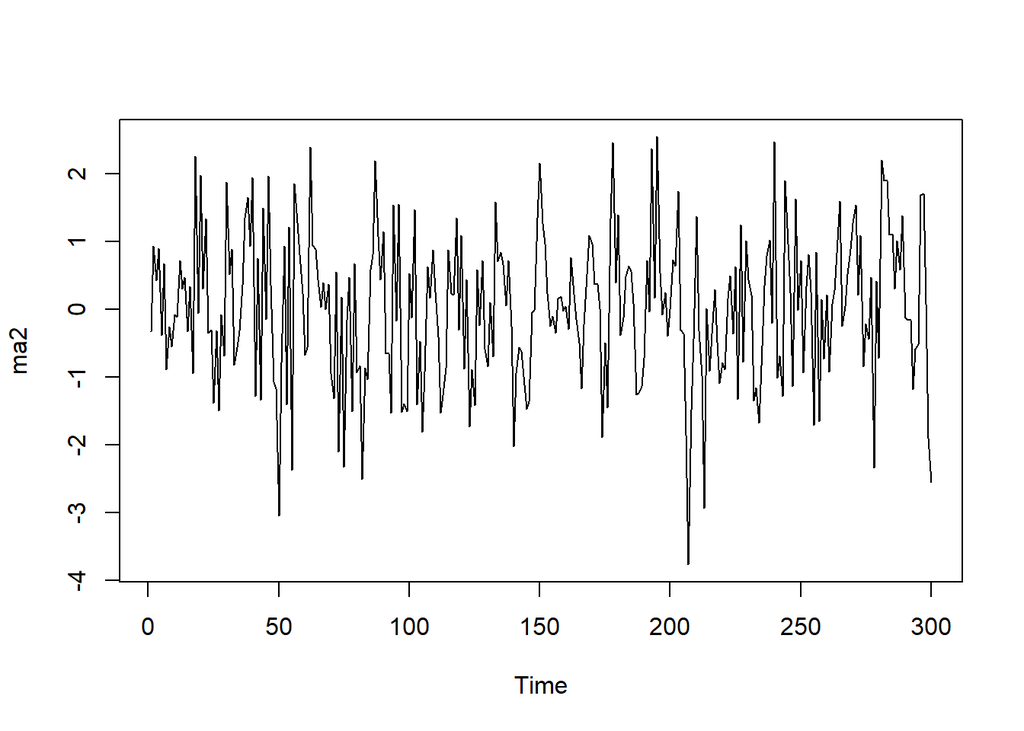

```r
ts.plot(ma2)
```

Berdasarkan plot time series, terlihat bahwa data MA(2) yang dibangkitkan stasioner dalam rataan

### Plot ACF

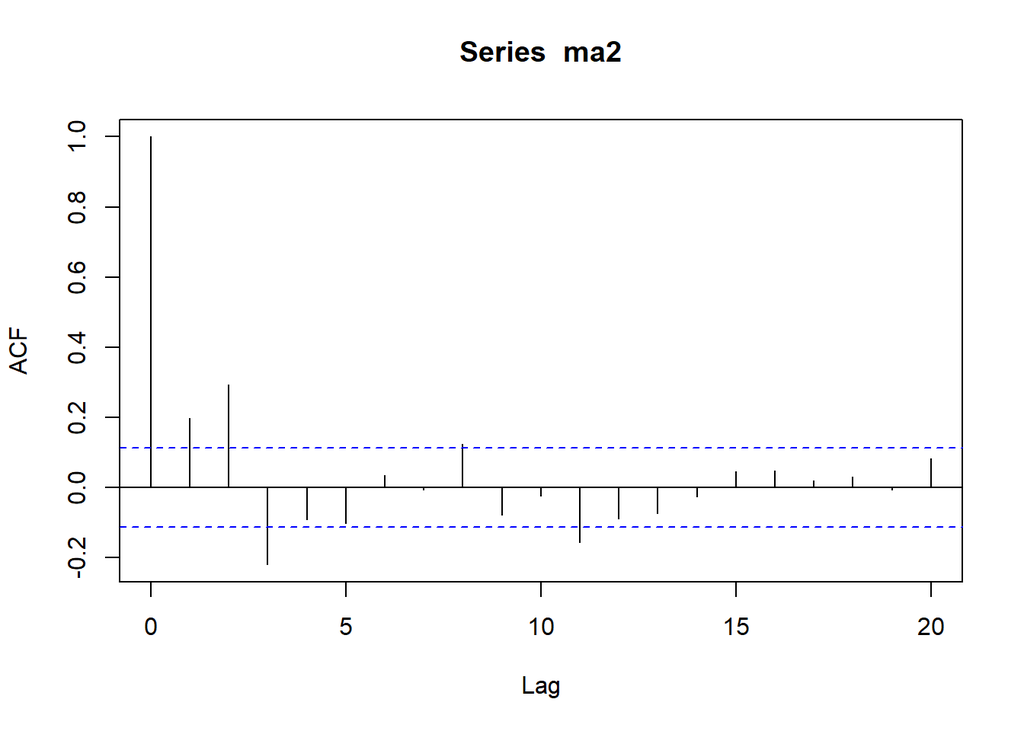

```r
acf(ma2,lag.max = 20)
```

### Plot PACF

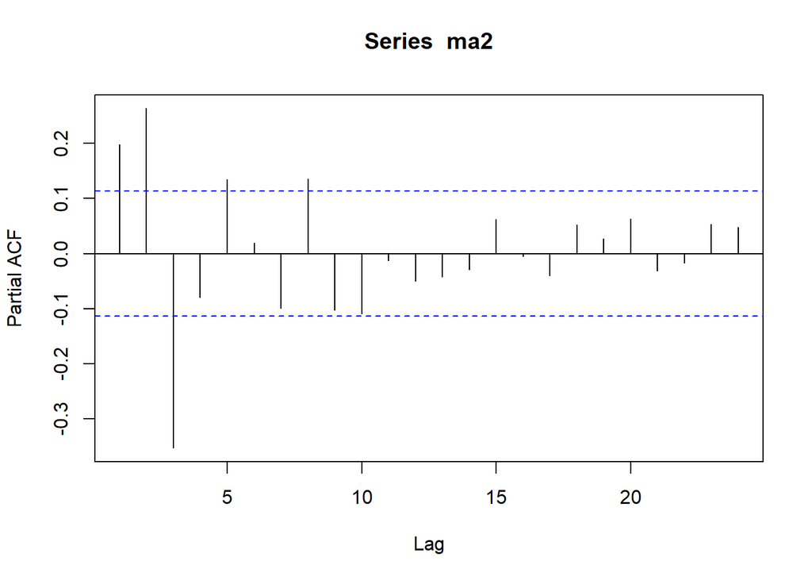

```r
pacf(ma2)
```

Berdasarkan plot PACF tersebut, terlihat bahwa plot PACF cenderung *tails off* dan membentuk gelombang sinus

### Plot EACF

```r
TSA::eacf(ma2)
```

```
## AR/MA
##   0 1 2 3 4 5 6 7 8 9 10 11 12 13
## 0 x x x o o o o x o o x  o  o  o
## 1 x x x o o o o o x o x  o  o  o
## 2 x x x x o o o o o o x  o  o  o
## 3 x x o x x o o o x o o  o  o  o
## 4 x x o o x x o o x o o  o  o  o
## 5 x x o o o x o o o o o  o  o  o
## 6 x x o o o x x o x o o  o  o  o
## 7 x x o x o x x o o o o  o  o  o
```

### Scatterplot Antar Lag

#### Korelasi antara $Y_t$ dengan $Y_{t-1}$

```r
#Yt
yt_ma <- ma2[-1]
yt_ma
```

```
##   [1]  0.9341366727  0.4243349404  0.8974894815 -0.3841558874  0.6729944896
##   [6] -0.8885207523 -0.2612462752 -0.5492143643 -0.0836883610 -0.1091924818
##  [11]  0.7169515952  0.2983353297  0.4639393911 -0.3265532299  0.3377245331
##  [16] -0.9427842306  2.2512849031 -0.0622597632  1.9750027176  0.3047315493
##  [21]  1.3366254832 -0.3478405113 -0.3001594610 -1.3842292528 -0.3202144293
##  [26] -1.4974845796 -0.0774490729 -0.6869208418  1.8691757931  0.5103525002
##  [31]  0.8880600332 -0.8172494857 -0.5645160554 -0.3198186008  0.3574098217
##  [36]  1.3420762517  1.6467569199  0.9256929647  1.9446730036 -1.2764717799
##  [41]  0.7540792312 -1.3392017743  1.4870380498 -0.1479179553  1.9670281852
##  [46]  0.3533411686 -1.0697048094 -1.1722570942 -3.0446163492 -0.7848116395
##  [51]  0.9258528713 -1.4056202968  1.2101733644 -2.3697952524  1.8536206597
##  [56]  1.2719523293  0.8085910707  0.2312427134 -0.6769534628 -0.5636186324
##  [61]  2.3890990883  0.9352875745  0.8880840314  0.4306847332  0.0290743007
##  [66]  0.3935562342  0.0005583003  0.3699571540 -0.9402882867 -1.3188196266
##  [71]  0.5449406154 -2.1001389139  0.1770243613 -2.3196860725 -0.1568220139
```

[output cut: 45 more lines]

```r
#Yt-1
yt_1_ma <- ma2[-300]
yt_1_ma
```

```
##   [1] -0.3276200340  0.9341366727  0.4243349404  0.8974894815 -0.3841558874
##   [6]  0.6729944896 -0.8885207523 -0.2612462752 -0.5492143643 -0.0836883610
##  [11] -0.1091924818  0.7169515952  0.2983353297  0.4639393911 -0.3265532299
##  [16]  0.3377245331 -0.9427842306  2.2512849031 -0.0622597632  1.9750027176
##  [21]  0.3047315493  1.3366254832 -0.3478405113 -0.3001594610 -1.3842292528
##  [26] -0.3202144293 -1.4974845796 -0.0774490729 -0.6869208418  1.8691757931
##  [31]  0.5103525002  0.8880600332 -0.8172494857 -0.5645160554 -0.3198186008
##  [36]  0.3574098217  1.3420762517  1.6467569199  0.9256929647  1.9446730036
##  [41] -1.2764717799  0.7540792312 -1.3392017743  1.4870380498 -0.1479179553
##  [46]  1.9670281852  0.3533411686 -1.0697048094 -1.1722570942 -3.0446163492
##  [51] -0.7848116395  0.9258528713 -1.4056202968  1.2101733644 -2.3697952524
##  [56]  1.8536206597  1.2719523293  0.8085910707  0.2312427134 -0.6769534628
##  [61] -0.5636186324  2.3890990883  0.9352875745  0.8880840314  0.4306847332
##  [66]  0.0290743007  0.3935562342  0.0005583003  0.3699571540 -0.9402882867
##  [71] -1.3188196266  0.5449406154 -2.1001389139  0.1770243613 -2.3196860725
```

[output cut: 45 more lines]

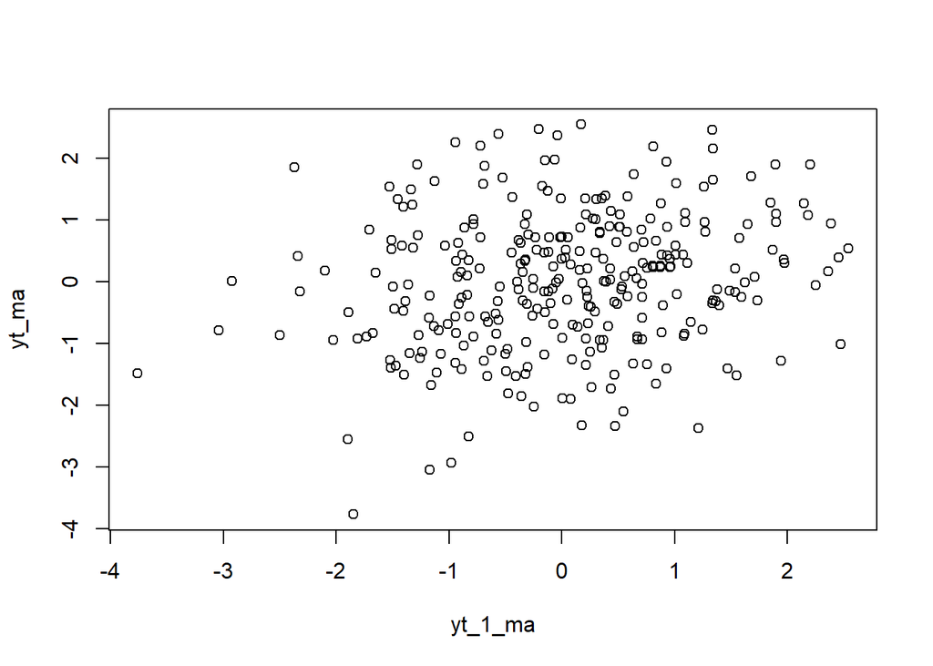

```r
plot(y=yt_ma,x=yt_1_ma)
```

Berdasarkan scatterplot tersebut, terlihat bahwa terdapat hubungan positif antara $Y_t$ dengan $Y_{t-1}$. Hal ini sesuai dengan teori yang ada

```r
cor(yt_ma,yt_1_ma)
```

```
## [1] 0.2002694
```

#### Korelasi antara $Y_t$ dengan $Y_{t-2}$

```r
#Yt
yt_ma2 <- ma2[-c(1,2)]
yt_ma2
```

```
##   [1]  0.4243349404  0.8974894815 -0.3841558874  0.6729944896 -0.8885207523
##   [6] -0.2612462752 -0.5492143643 -0.0836883610 -0.1091924818  0.7169515952
##  [11]  0.2983353297  0.4639393911 -0.3265532299  0.3377245331 -0.9427842306
##  [16]  2.2512849031 -0.0622597632  1.9750027176  0.3047315493  1.3366254832
##  [21] -0.3478405113 -0.3001594610 -1.3842292528 -0.3202144293 -1.4974845796
##  [26] -0.0774490729 -0.6869208418  1.8691757931  0.5103525002  0.8880600332
##  [31] -0.8172494857 -0.5645160554 -0.3198186008  0.3574098217  1.3420762517
##  [36]  1.6467569199  0.9256929647  1.9446730036 -1.2764717799  0.7540792312
##  [41] -1.3392017743  1.4870380498 -0.1479179553  1.9670281852  0.3533411686
##  [46] -1.0697048094 -1.1722570942 -3.0446163492 -0.7848116395  0.9258528713
##  [51] -1.4056202968  1.2101733644 -2.3697952524  1.8536206597  1.2719523293
##  [56]  0.8085910707  0.2312427134 -0.6769534628 -0.5636186324  2.3890990883
##  [61]  0.9352875745  0.8880840314  0.4306847332  0.0290743007  0.3935562342
##  [66]  0.0005583003  0.3699571540 -0.9402882867 -1.3188196266  0.5449406154
##  [71] -2.1001389139  0.1770243613 -2.3196860725 -0.1568220139  0.4641506610
```

[output cut: 45 more lines]

```r
#Yt-2
yt_2_ma <- ma2[-c(299,300)]
yt_2_ma
```

```
##   [1] -0.3276200340  0.9341366727  0.4243349404  0.8974894815 -0.3841558874
##   [6]  0.6729944896 -0.8885207523 -0.2612462752 -0.5492143643 -0.0836883610
##  [11] -0.1091924818  0.7169515952  0.2983353297  0.4639393911 -0.3265532299
##  [16]  0.3377245331 -0.9427842306  2.2512849031 -0.0622597632  1.9750027176
##  [21]  0.3047315493  1.3366254832 -0.3478405113 -0.3001594610 -1.3842292528
##  [26] -0.3202144293 -1.4974845796 -0.0774490729 -0.6869208418  1.8691757931
##  [31]  0.5103525002  0.8880600332 -0.8172494857 -0.5645160554 -0.3198186008
##  [36]  0.3574098217  1.3420762517  1.6467569199  0.9256929647  1.9446730036
##  [41] -1.2764717799  0.7540792312 -1.3392017743  1.4870380498 -0.1479179553
##  [46]  1.9670281852  0.3533411686 -1.0697048094 -1.1722570942 -3.0446163492
##  [51] -0.7848116395  0.9258528713 -1.4056202968  1.2101733644 -2.3697952524
##  [56]  1.8536206597  1.2719523293  0.8085910707  0.2312427134 -0.6769534628
##  [61] -0.5636186324  2.3890990883  0.9352875745  0.8880840314  0.4306847332
##  [66]  0.0290743007  0.3935562342  0.0005583003  0.3699571540 -0.9402882867
##  [71] -1.3188196266  0.5449406154 -2.1001389139  0.1770243613 -2.3196860725
```

[output cut: 45 more lines]

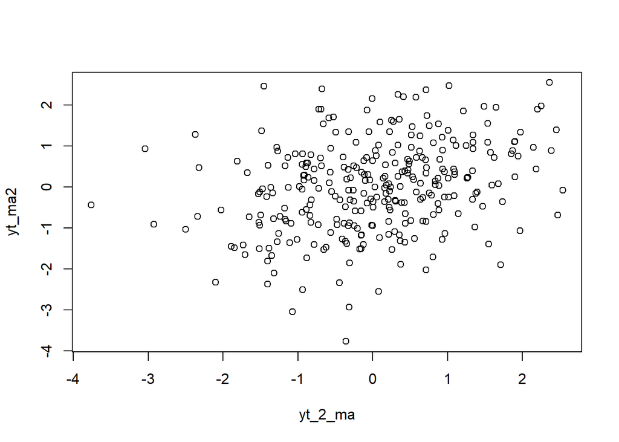

```r
plot(y=yt_ma2,x=yt_2_ma)
```

Berdasarkan scatterplot tersebut, terlihat bahwa terdapat hubungan agak positif antara $Y_t$ dengan $Y_{t-2}$. Hal ini sesuai dengan teori yang ada

```r
cor(yt_ma2,yt_2_ma)
```

```
## [1] 0.2970496
```

#### Korelasi antara $Y_t$ dengan $Y_{t-3}$

```r
#Yt
yt_ma3 <- ma2[-c(1,2,3)]
yt_ma3
```

```
##   [1]  0.8974894815 -0.3841558874  0.6729944896 -0.8885207523 -0.2612462752
##   [6] -0.5492143643 -0.0836883610 -0.1091924818  0.7169515952  0.2983353297
##  [11]  0.4639393911 -0.3265532299  0.3377245331 -0.9427842306  2.2512849031
##  [16] -0.0622597632  1.9750027176  0.3047315493  1.3366254832 -0.3478405113
##  [21] -0.3001594610 -1.3842292528 -0.3202144293 -1.4974845796 -0.0774490729
##  [26] -0.6869208418  1.8691757931  0.5103525002  0.8880600332 -0.8172494857
##  [31] -0.5645160554 -0.3198186008  0.3574098217  1.3420762517  1.6467569199
##  [36]  0.9256929647  1.9446730036 -1.2764717799  0.7540792312 -1.3392017743
##  [41]  1.4870380498 -0.1479179553  1.9670281852  0.3533411686 -1.0697048094
##  [46] -1.1722570942 -3.0446163492 -0.7848116395  0.9258528713 -1.4056202968
##  [51]  1.2101733644 -2.3697952524  1.8536206597  1.2719523293  0.8085910707
##  [56]  0.2312427134 -0.6769534628 -0.5636186324  2.3890990883  0.9352875745
##  [61]  0.8880840314  0.4306847332  0.0290743007  0.3935562342  0.0005583003
##  [66]  0.3699571540 -0.9402882867 -1.3188196266  0.5449406154 -2.1001389139
##  [71]  0.1770243613 -2.3196860725 -0.1568220139  0.4641506610 -1.5087003090
```

[output cut: 45 more lines]

```r
#Yt-3
yt_3_ma <- ma2[-c(298,299,300)]
yt_3_ma
```

```
##   [1] -0.3276200340  0.9341366727  0.4243349404  0.8974894815 -0.3841558874
##   [6]  0.6729944896 -0.8885207523 -0.2612462752 -0.5492143643 -0.0836883610
##  [11] -0.1091924818  0.7169515952  0.2983353297  0.4639393911 -0.3265532299
##  [16]  0.3377245331 -0.9427842306  2.2512849031 -0.0622597632  1.9750027176
##  [21]  0.3047315493  1.3366254832 -0.3478405113 -0.3001594610 -1.3842292528
##  [26] -0.3202144293 -1.4974845796 -0.0774490729 -0.6869208418  1.8691757931
##  [31]  0.5103525002  0.8880600332 -0.8172494857 -0.5645160554 -0.3198186008
##  [36]  0.3574098217  1.3420762517  1.6467569199  0.9256929647  1.9446730036
##  [41] -1.2764717799  0.7540792312 -1.3392017743  1.4870380498 -0.1479179553
##  [46]  1.9670281852  0.3533411686 -1.0697048094 -1.1722570942 -3.0446163492
##  [51] -0.7848116395  0.9258528713 -1.4056202968  1.2101733644 -2.3697952524
##  [56]  1.8536206597  1.2719523293  0.8085910707  0.2312427134 -0.6769534628
##  [61] -0.5636186324  2.3890990883  0.9352875745  0.8880840314  0.4306847332
##  [66]  0.0290743007  0.3935562342  0.0005583003  0.3699571540 -0.9402882867
##  [71] -1.3188196266  0.5449406154 -2.1001389139  0.1770243613 -2.3196860725
```

[output cut: 45 more lines]

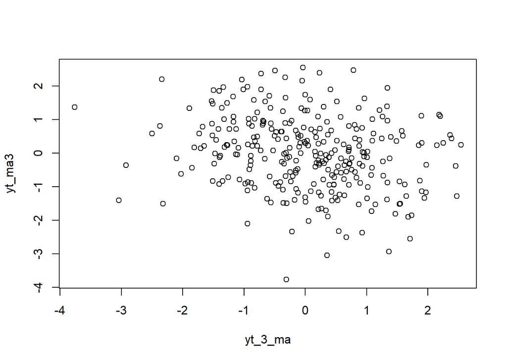

```r
plot(y=yt_ma3,x=yt_3_ma)
```

Berdasarkan scatterplot tersebut, terlihat bahwa cenderung tidak terdapat hubungan positif antara $Y_t$ dengan $Y_{t-3}$. Hal ini sesuai dengan teori yang ada

```r
cor(yt_ma3,yt_3_ma)
```

```
## [1] -0.2234808
```

## Pembangkitan Proses AR

```r
set.seed(100)
```

$$Y_t = e_t+0.5Y_{t-1}+0.2Y_{t-2}$$

```r
n<-length(wn)
n
```

```
## [1] 300
```

```r
ar <- c(1:n)
for (i in 3:n) {ar[i]<-wn[i]+0.5*ar[i-1]+0.2*ar[i-2]}
ar
```

```
##   [1]  1.000000000  2.000000000  1.121082910  1.847326265  1.264850985
##   [6]  1.320520833  0.331439929  1.144356842 -0.186793019 -0.224387273
##  [11] -0.059666096  0.021563958 -0.202785193  0.642760695  0.404202810
##  [16]  0.301336835 -0.157345267  0.492450991 -0.699057744  2.059258149
##  [21]  0.451727545  1.401776019  1.053194810  1.580357205  0.186438440
##  [26] -0.029159908 -0.697513816 -0.123644358 -1.359054404 -0.457180081
##  [31] -0.591514483  1.370182364  0.428858674  0.377272315 -0.415606429
##  [36] -0.354142981 -0.077285093  0.307852144  1.203871380  1.633708136
##  [41]  0.955999106  2.207944669 -0.481603477  0.823654586 -0.206776753
##  [46]  1.383573496  0.286991071  1.739275977  0.970815270 -1.045393051
##  [51] -0.775595654 -2.335474384 -1.143991474  0.858375086 -2.071536238
##  [56]  0.116371037 -1.754947345  0.970672958  1.515645740  0.113105586
##  [61]  0.097686167  0.002620173 -0.358036237  2.403464844  1.259959312
##  [66]  0.397647644  1.088809928  0.825626084  0.560658079  0.352964381
##  [71]  0.737517080 -0.625004255 -1.327418034  0.859811879 -1.897673687
```

[output cut: 45 more lines]

Selain menggunakan cara di atas, pembangkitan proses AR dapat dilakukan dengan fungsi `arima.sim()` sebagai berikut.

```r
ar2 <- arima.sim(list(order=c(2,0,0), ar=c(0.5,0.2)), n=300)
ar2
```

```
## Time Series:
## Start = 1
## End = 300
## Frequency = 1
##   [1] -0.031936661 -0.699630667 -0.125258133 -1.360284662 -0.458117965
##   [6] -0.592229477  1.369637291  0.428443138  0.376955532 -0.415847927
##  [11] -0.354327087 -0.077425445  0.307745146  1.203789811  1.633645952
##  [16]  0.955951700  2.207908529 -0.481631028  0.823633583 -0.206792765
##  [21]  1.383561290  0.286981765  1.739268883  0.970809862 -1.045397174
##  [26] -0.775598797 -2.335476780 -1.143993301  0.858373694 -2.071537299
##  [31]  0.116370228 -1.754947962  0.970672487  1.515645381  0.113105313
##  [36]  0.097685958  0.002620014 -0.358036358  2.403464751  1.259959241
##  [41]  0.397647591  1.088809887  0.825626053  0.560658056  0.352964363
##  [46]  0.737517066 -0.625004265 -1.327418042  0.859811873 -1.897673691
##  [51] -0.764124750 -1.849125463 -0.806848188  0.235202687 -2.118173049
```

[output cut: 49 more lines]

## Karakteristik AR(2)

### Plot Time Series

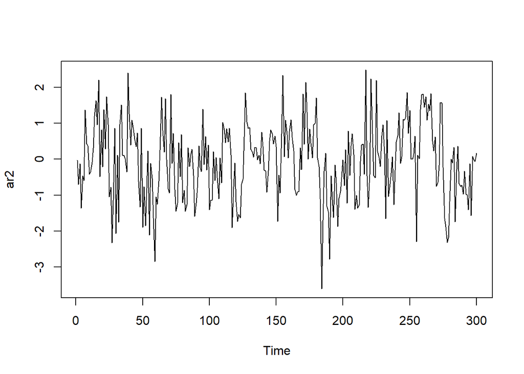

```r
ts.plot(ar2)
```

Berdasarkan plot time series tersebut terlihat bahwa data cenderung stasioner pada rataan

### Plot ACF

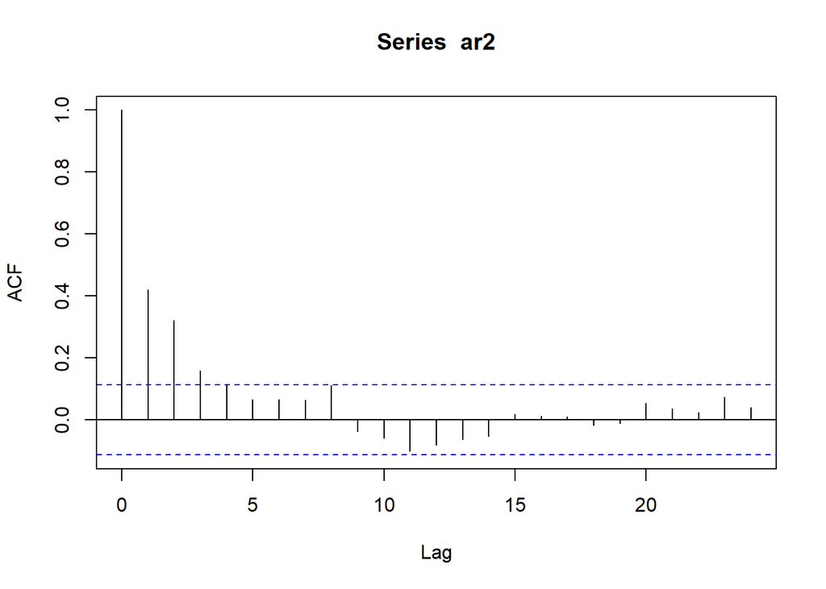

```r
acf(ar2)
```

Berdasarkan plot ACF tersebut terlihat bahwa plot ACF cenderung *tails off* dan cenderung membentuk pola grafik sinus

### Plot PACF

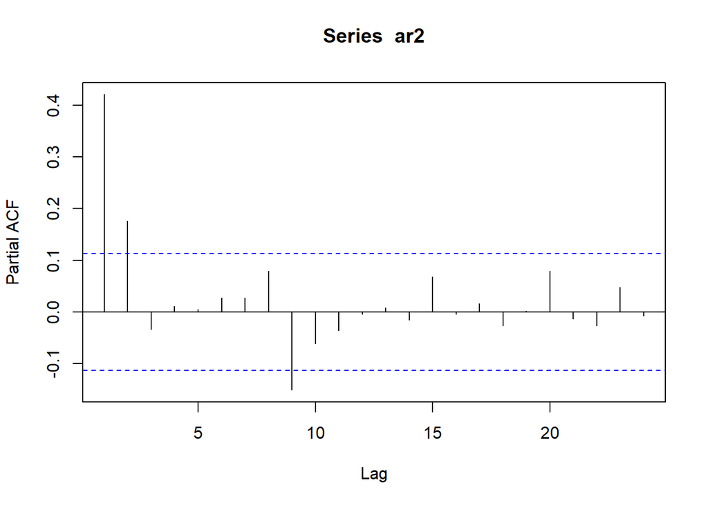

```r
pacf(ar2)
```

### Plot EACF

```r
TSA::eacf(ar2)
```

```
## AR/MA
##   0 1 2 3 4 5 6 7 8 9 10 11 12 13
## 0 x x x o o o o o o o o  o  o  o
## 1 x x o o o o o o o o o  o  o  o
## 2 x o o o o o o o o o o  o  o  o
## 3 x o o o o o o o o o o  o  o  o
## 4 x o o o o o o o o o o  o  o  o
## 5 x x o o o o o x o o o  o  o  o
## 6 x x o o o o o x o o o  o  o  o
## 7 x o o o x o o x o o o  o  o  o
```

Berdasarkan pola segitiga nol pada plot EACF, terlihat bahwa segitiga nol berada pada ordo AR(0) dan ordo MA(3)

### Scatterplot Antar Lag

#### Korelasi antara $Y_t$ dengan $Y_{t-1}$

```r
#Yt
yt_ar <- ar2[-1]
yt_ar
```

```
##   [1] -0.699630667 -0.125258133 -1.360284662 -0.458117965 -0.592229477
##   [6]  1.369637291  0.428443138  0.376955532 -0.415847927 -0.354327087
##  [11] -0.077425445  0.307745146  1.203789811  1.633645952  0.955951700
##  [16]  2.207908529 -0.481631028  0.823633583 -0.206792765  1.383561290
##  [21]  0.286981765  1.739268883  0.970809862 -1.045397174 -0.775598797
##  [26] -2.335476780 -1.143993301  0.858373694 -2.071537299  0.116370228
##  [31] -1.754947962  0.970672487  1.515645381  0.113105313  0.097685958
##  [36]  0.002620014 -0.358036358  2.403464751  1.259959241  0.397647591
##  [41]  1.088809887  0.825626053  0.560658056  0.352964363  0.737517066
##  [46] -0.625004265 -1.327418042  0.859811873 -1.897673691 -0.764124750
##  [51] -1.849125463 -0.806848188  0.235202687 -2.118173049 -0.115223715
##  [56] -0.531242234 -1.634015171 -2.854467566 -1.044455234 -1.251026162
##  [61] -0.618036255  0.258138716  1.732637861  0.814176381  0.196493472
##  [66]  1.689383442 -0.008966987 -0.824178045 -0.944178875  1.808757711
##  [71] -0.116952717  0.716795032 -0.843676168 -1.452513836 -1.227915503
```

[output cut: 45 more lines]

```r
#Yt-1
yt_1_ar <- ar2[-300]
yt_1_ar
```

```
##   [1] -0.031936661 -0.699630667 -0.125258133 -1.360284662 -0.458117965
##   [6] -0.592229477  1.369637291  0.428443138  0.376955532 -0.415847927
##  [11] -0.354327087 -0.077425445  0.307745146  1.203789811  1.633645952
##  [16]  0.955951700  2.207908529 -0.481631028  0.823633583 -0.206792765
##  [21]  1.383561290  0.286981765  1.739268883  0.970809862 -1.045397174
##  [26] -0.775598797 -2.335476780 -1.143993301  0.858373694 -2.071537299
##  [31]  0.116370228 -1.754947962  0.970672487  1.515645381  0.113105313
##  [36]  0.097685958  0.002620014 -0.358036358  2.403464751  1.259959241
##  [41]  0.397647591  1.088809887  0.825626053  0.560658056  0.352964363
##  [46]  0.737517066 -0.625004265 -1.327418042  0.859811873 -1.897673691
##  [51] -0.764124750 -1.849125463 -0.806848188  0.235202687 -2.118173049
##  [56] -0.115223715 -0.531242234 -1.634015171 -2.854467566 -1.044455234
##  [61] -1.251026162 -0.618036255  0.258138716  1.732637861  0.814176381
##  [66]  0.196493472  1.689383442 -0.008966987 -0.824178045 -0.944178875
##  [71]  1.808757711 -0.116952717  0.716795032 -0.843676168 -1.452513836
```

[output cut: 45 more lines]

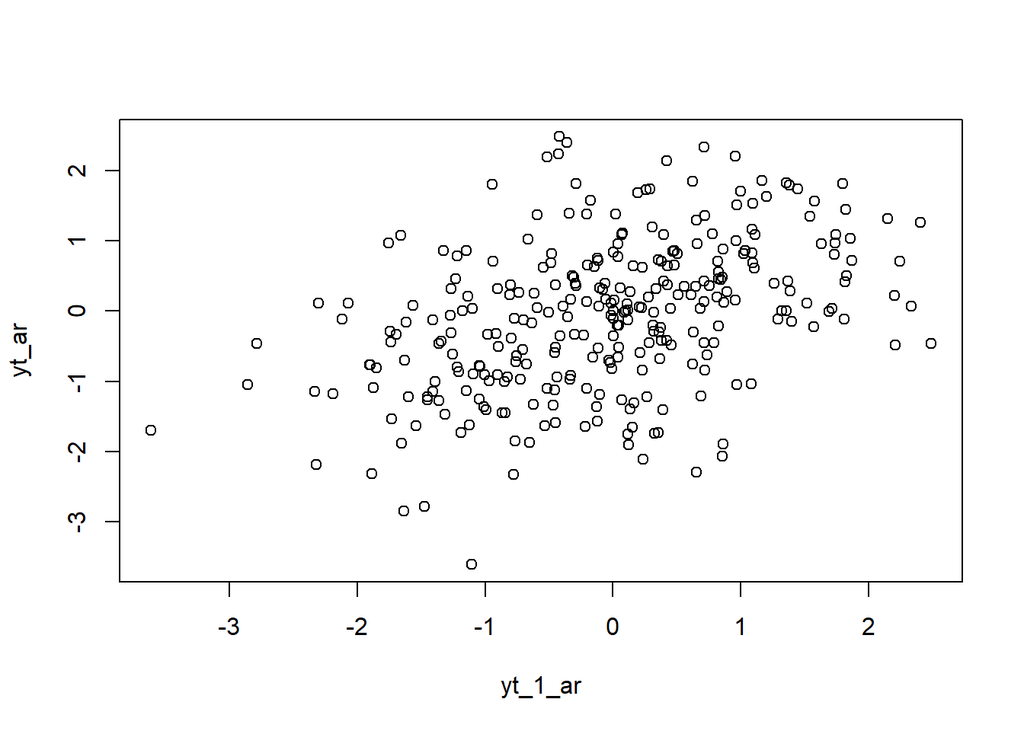

```r
plot(y=yt_ar,x=yt_1_ar)
```

Berdasarkan scatterplot tersebut, terlihat bahwa terdapat hubungan positif antara $Y_t$ dengan $Y_{t-1}$. Hal ini sesuai dengan teori yang ada

```r
cor(yt_ar,yt_1_ar)
```

```
## [1] 0.4207644
```

#### Korelasi antara $Y_t$ dengan $Y_{t-2}$

```r
#Yt
yt_ar2 <- ar2[-c(1,2)]
yt_ar2
```

```
##   [1] -0.125258133 -1.360284662 -0.458117965 -0.592229477  1.369637291
##   [6]  0.428443138  0.376955532 -0.415847927 -0.354327087 -0.077425445
##  [11]  0.307745146  1.203789811  1.633645952  0.955951700  2.207908529
##  [16] -0.481631028  0.823633583 -0.206792765  1.383561290  0.286981765
##  [21]  1.739268883  0.970809862 -1.045397174 -0.775598797 -2.335476780
##  [26] -1.143993301  0.858373694 -2.071537299  0.116370228 -1.754947962
##  [31]  0.970672487  1.515645381  0.113105313  0.097685958  0.002620014
##  [36] -0.358036358  2.403464751  1.259959241  0.397647591  1.088809887
##  [41]  0.825626053  0.560658056  0.352964363  0.737517066 -0.625004265
##  [46] -1.327418042  0.859811873 -1.897673691 -0.764124750 -1.849125463
##  [51] -0.806848188  0.235202687 -2.118173049 -0.115223715 -0.531242234
##  [56] -1.634015171 -2.854467566 -1.044455234 -1.251026162 -0.618036255
##  [61]  0.258138716  1.732637861  0.814176381  0.196493472  1.689383442
##  [66] -0.008966987 -0.824178045 -0.944178875  1.808757711 -0.116952717
##  [71]  0.716795032 -0.843676168 -1.452513836 -1.227915503  0.458653188
```

[output cut: 45 more lines]

```r
#Yt-2
yt_2_ar <- ar2[-c(299,300)]
yt_2_ar
```

```
##   [1] -0.031936661 -0.699630667 -0.125258133 -1.360284662 -0.458117965
##   [6] -0.592229477  1.369637291  0.428443138  0.376955532 -0.415847927
##  [11] -0.354327087 -0.077425445  0.307745146  1.203789811  1.633645952
##  [16]  0.955951700  2.207908529 -0.481631028  0.823633583 -0.206792765
##  [21]  1.383561290  0.286981765  1.739268883  0.970809862 -1.045397174
##  [26] -0.775598797 -2.335476780 -1.143993301  0.858373694 -2.071537299
##  [31]  0.116370228 -1.754947962  0.970672487  1.515645381  0.113105313
##  [36]  0.097685958  0.002620014 -0.358036358  2.403464751  1.259959241
##  [41]  0.397647591  1.088809887  0.825626053  0.560658056  0.352964363
##  [46]  0.737517066 -0.625004265 -1.327418042  0.859811873 -1.897673691
##  [51] -0.764124750 -1.849125463 -0.806848188  0.235202687 -2.118173049
##  [56] -0.115223715 -0.531242234 -1.634015171 -2.854467566 -1.044455234
##  [61] -1.251026162 -0.618036255  0.258138716  1.732637861  0.814176381
##  [66]  0.196493472  1.689383442 -0.008966987 -0.824178045 -0.944178875
##  [71]  1.808757711 -0.116952717  0.716795032 -0.843676168 -1.452513836
```

[output cut: 45 more lines]

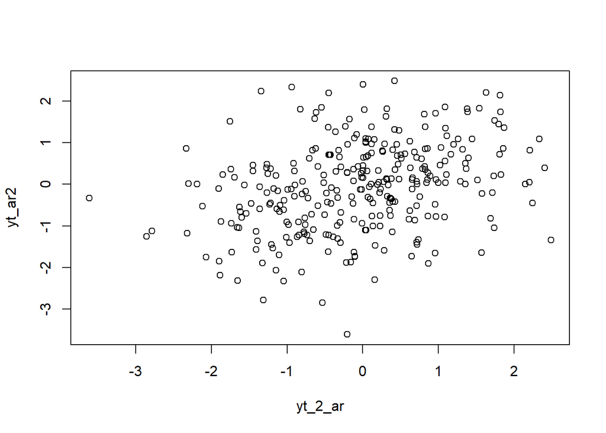

```r
plot(y=yt_ar2,x=yt_2_ar)
```

Berdasarkan scatterplot tersebut, terlihat bahwa cenderung terdapat hubungan positif antara $Y_t$ dengan $Y_{t-2}$. Hal ini sesuai dengan teori yang ada

```r
cor(yt_ar2,yt_2_ar)
```

```
## [1] 0.3221638
```

```r
#Yt
yt_ar3 <- ar2[-c(1,2,3)]
yt_ar3
```

```
##   [1] -1.360284662 -0.458117965 -0.592229477  1.369637291  0.428443138
##   [6]  0.376955532 -0.415847927 -0.354327087 -0.077425445  0.307745146
##  [11]  1.203789811  1.633645952  0.955951700  2.207908529 -0.481631028
##  [16]  0.823633583 -0.206792765  1.383561290  0.286981765  1.739268883
##  [21]  0.970809862 -1.045397174 -0.775598797 -2.335476780 -1.143993301
##  [26]  0.858373694 -2.071537299  0.116370228 -1.754947962  0.970672487
##  [31]  1.515645381  0.113105313  0.097685958  0.002620014 -0.358036358
##  [36]  2.403464751  1.259959241  0.397647591  1.088809887  0.825626053
##  [41]  0.560658056  0.352964363  0.737517066 -0.625004265 -1.327418042
##  [46]  0.859811873 -1.897673691 -0.764124750 -1.849125463 -0.806848188
##  [51]  0.235202687 -2.118173049 -0.115223715 -0.531242234 -1.634015171
##  [56] -2.854467566 -1.044455234 -1.251026162 -0.618036255  0.258138716
##  [61]  1.732637861  0.814176381  0.196493472  1.689383442 -0.008966987
##  [66] -0.824178045 -0.944178875  1.808757711 -0.116952717  0.716795032
##  [71] -0.843676168 -1.452513836 -1.227915503  0.458653188 -0.485403846
```

[output cut: 45 more lines]

```r
#Yt-2
yt_3_ar <- ar2[-c(298,299,300)]
yt_3_ar
```

```
##   [1] -0.031936661 -0.699630667 -0.125258133 -1.360284662 -0.458117965
##   [6] -0.592229477  1.369637291  0.428443138  0.376955532 -0.415847927
##  [11] -0.354327087 -0.077425445  0.307745146  1.203789811  1.633645952
##  [16]  0.955951700  2.207908529 -0.481631028  0.823633583 -0.206792765
##  [21]  1.383561290  0.286981765  1.739268883  0.970809862 -1.045397174
##  [26] -0.775598797 -2.335476780 -1.143993301  0.858373694 -2.071537299
##  [31]  0.116370228 -1.754947962  0.970672487  1.515645381  0.113105313
##  [36]  0.097685958  0.002620014 -0.358036358  2.403464751  1.259959241
##  [41]  0.397647591  1.088809887  0.825626053  0.560658056  0.352964363
##  [46]  0.737517066 -0.625004265 -1.327418042  0.859811873 -1.897673691
##  [51] -0.764124750 -1.849125463 -0.806848188  0.235202687 -2.118173049
##  [56] -0.115223715 -0.531242234 -1.634015171 -2.854467566 -1.044455234
##  [61] -1.251026162 -0.618036255  0.258138716  1.732637861  0.814176381
##  [66]  0.196493472  1.689383442 -0.008966987 -0.824178045 -0.944178875
##  [71]  1.808757711 -0.116952717  0.716795032 -0.843676168 -1.452513836
```

[output cut: 45 more lines]

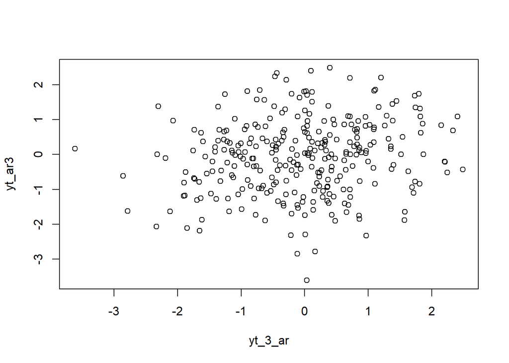

```r
plot(y=yt_ar3,x=yt_3_ar)
```

```r
cor(yt_ar3,yt_3_ar)
```

```
## [1] 0.1592218
```

## Fungsi pembangkitan ARMA

```r
set.seed(100)
n = length(wn)
phi1 = 0.5
phi2 = 0.2

theta1 = 0.4
theta2 = 0.6

y.arma=c(1:n)
for (i in 5:n){y.arma[i] = phi1*y.arma[i-1] + phi2*y.arma[i-2] + theta1*wn[i-1] + theta2*wn[i-2] + wn[i]}
y.arma
```

```
##   [1]  1.000000000  2.000000000  3.000000000  4.000000000  3.024334940
##   [6]  3.209656952  1.825539577  2.227695668  0.590434997  0.479510357
##  [11] -0.191372186 -0.083472383 -0.189203111  0.605655563  0.563322489
##  [16]  0.866731748  0.219477142  0.620809454 -0.588484075  2.081204756
##  [21]  0.860645800  2.821566569  1.887643994  2.844760794  1.452068684
##  [26]  0.994827040 -0.596401996 -0.419450019 -1.826489988 -1.074584071
##  [31] -1.589510875  0.859503541  0.622202096  1.371061789 -0.007278172
##  [36] -0.293942783 -0.468245627  0.064498452  1.280676352  2.299994786
##  [41]  2.331825628  3.570584775  0.975185733  1.955789053 -0.166270101
##  [46]  1.795060810  0.716358429  2.684219562  1.838722635  0.386500421
##  [51] -0.611262357 -3.272947444 -2.543537833 -1.000505534 -2.414580630
##  [56] -0.197218057 -2.951320407  0.338516845  0.850946670  1.301767775
##  [61]  1.052315935  0.109558060 -0.298376416  2.261822492  2.006523538
##  [66]  2.343710299  2.003844590  1.499738655  1.544194480  1.072603271
##  [71]  1.215097686 -0.118218790 -1.134909484 -0.046157885 -2.350199753
```

[output cut: 45 more lines]

Pembangkitan ARMA(p,q) juga dapat dilakukan dengan fungsi `arima.sim` sebagai berikut.

```r
arma22 <- arima.sim(list(order=c(2,0,2), ar = c(0.5,0.2), ma =c(0.4,0.6)), n=300)
arma22
```

```
## Time Series:
## Start = 1
## End = 300
## Frequency = 1
##   [1] -0.423982089 -1.829945001 -1.077217991 -1.591518838  0.857972776
##   [6]  0.621035121  1.370172149 -0.007956387 -0.294459819 -0.468639788
##  [11]  0.064197964  1.280447276  2.299820151  2.331692495  3.570483281
##  [16]  0.975108360  1.955730067 -0.166315069  1.795026529  0.716332295
##  [21]  2.684199639  1.838707447  0.386488842 -0.611271184 -3.272954173
##  [26] -2.543542963 -1.000509445 -2.414583612 -0.197220330 -2.951322140
##  [31]  0.338515524  0.850945663  1.301767007  1.052315350  0.109557613
##  [36] -0.298376756  2.261822233  2.006523340  2.343710148  2.003844475
##  [41]  1.499738568  1.544194413  1.072603220  1.215097647 -0.118218819
##  [46] -1.134909507 -0.046157902 -2.350199766 -1.007307102 -3.293379577
##  [51] -2.004973223 -1.197011866 -2.508200886 -0.821371322 -1.848235549
```

[output cut: 49 more lines]

### Plot Time Series

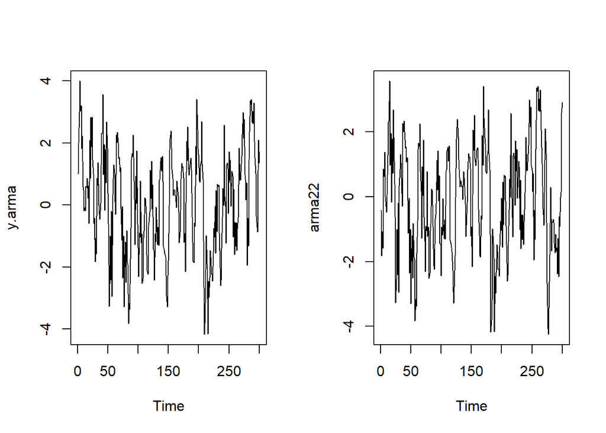

```r
par(mfrow = c(1, 2))
ts.plot(y.arma)
ts.plot(arma22)
```

```r
par(mfrow = c(1, 1))
```

Berdasarkan plot time series tersebut, terlihat bahwa model ARMA(2,2) cenderung stasioner dalam rataan

### Plot ACF

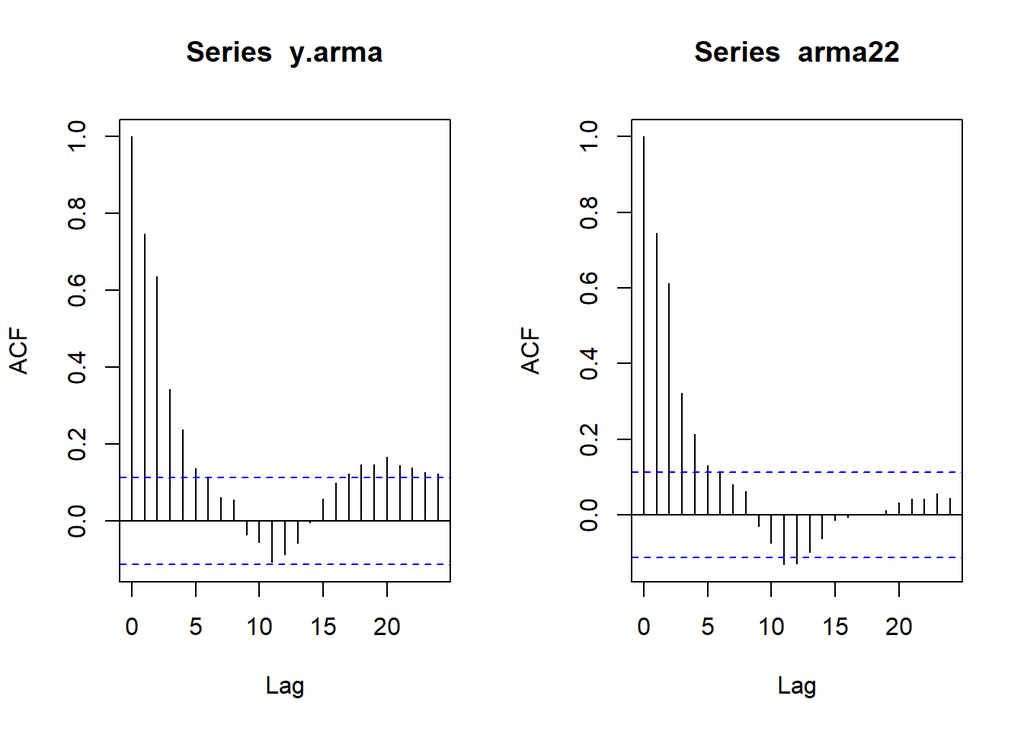

```r
par(mfrow = c(1, 2))
acf(y.arma)
acf(arma22)
```

```r
par(mfrow = c(1, 1))
```

Berdasarkan plot ACF tersebut, terlihat bahwa model ARMA(2,2) hasil simulasi memiliki plot ACF yang *tails off*, sesuai dengan teori yang ada

### Plot PACF

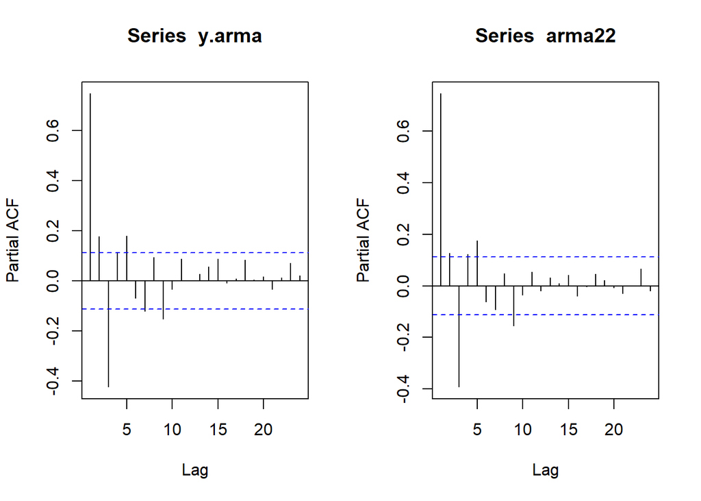

```r
par(mfrow = c(1, 2))
pacf(y.arma)
pacf(arma22)
```

```r
par(mfrow = c(1, 1))
```

### Plot EACF

```r
TSA::eacf(y.arma)
```

```
## AR/MA
##   0 1 2 3 4 5 6 7 8 9 10 11 12 13
## 0 x x x x x o o o o o o  o  o  o
## 1 x x x o x o o o o o x  o  o  o
## 2 x x o o o o o o o o x  o  o  o
## 3 x x o x o o o x o o o  o  o  o
## 4 x x x x o o o x o o o  o  o  o
## 5 x x x o x o o x o o o  o  o  o
## 6 x x o o x o x x o o o  o  o  o
## 7 x x x x x o o x o o o  o  o  o
```

```r
TSA::eacf(arma22)
```

```
## AR/MA
##   0 1 2 3 4 5 6 7 8 9 10 11 12 13
## 0 x x x x x o o o o o x  x  o  o
## 1 x x x o x o o o o o x  o  o  o
## 2 x x o o o o o o o o o  o  o  o
## 3 x x o x o o o x o o o  o  o  o
## 4 x x x o x o o x o o o  o  o  o
## 5 x x x o x o o x o o o  o  o  o
## 6 x x o o x o x x o o o  o  o  o
## 7 x x x x x x x x x o o  o  o  o
```

### Scatterplot Antar Lag

#### Korelasi antara $Y_t$ dengan $Y_{t-1}$

```r
#Yt
yt_arma <- arma22[-1]
yt_arma
```

```
##   [1] -1.829945001 -1.077217991 -1.591518838  0.857972776  0.621035121
##   [6]  1.370172149 -0.007956387 -0.294459819 -0.468639788  0.064197964
##  [11]  1.280447276  2.299820151  2.331692495  3.570483281  0.975108360
##  [16]  1.955730067 -0.166315069  1.795026529  0.716332295  2.684199639
##  [21]  1.838707447  0.386488842 -0.611271184 -3.272954173 -2.543542963
##  [26] -1.000509445 -2.414583612 -0.197220330 -2.951322140  0.338515524
##  [31]  0.850945663  1.301767007  1.052315350  0.109557613 -0.298376756
##  [36]  2.261822233  2.006523340  2.343710148  2.003844475  1.499738568
##  [41]  1.544194413  1.072603220  1.215097647 -0.118218819 -1.134909507
##  [46] -0.046157902 -2.350199766 -1.007307102 -3.293379577 -2.004973223
##  [51] -1.197011866 -2.508200886 -0.821371322 -1.848235549 -1.915646293
##  [56] -3.826818975 -3.166651363 -3.381488796 -1.745119860 -0.739691484
##  [61]  1.465071595  1.662114755  1.561746742  2.256486660  0.784682474
##  [66]  0.185865226 -1.279230285  0.936579335  0.040043042  1.755268572
##  [71] -0.627129785 -1.359907284 -2.315126738 -0.904021314 -1.038691872
```

[output cut: 45 more lines]

```r
#Yt-1
yt_1_arma <- arma22[-300]
yt_1_arma
```

```
##   [1] -0.423982089 -1.829945001 -1.077217991 -1.591518838  0.857972776
##   [6]  0.621035121  1.370172149 -0.007956387 -0.294459819 -0.468639788
##  [11]  0.064197964  1.280447276  2.299820151  2.331692495  3.570483281
##  [16]  0.975108360  1.955730067 -0.166315069  1.795026529  0.716332295
##  [21]  2.684199639  1.838707447  0.386488842 -0.611271184 -3.272954173
##  [26] -2.543542963 -1.000509445 -2.414583612 -0.197220330 -2.951322140
##  [31]  0.338515524  0.850945663  1.301767007  1.052315350  0.109557613
##  [36] -0.298376756  2.261822233  2.006523340  2.343710148  2.003844475
##  [41]  1.499738568  1.544194413  1.072603220  1.215097647 -0.118218819
##  [46] -1.134909507 -0.046157902 -2.350199766 -1.007307102 -3.293379577
##  [51] -2.004973223 -1.197011866 -2.508200886 -0.821371322 -1.848235549
##  [56] -1.915646293 -3.826818975 -3.166651363 -3.381488796 -1.745119860
##  [61] -0.739691484  1.465071595  1.662114755  1.561746742  2.256486660
##  [66]  0.784682474  0.185865226 -1.279230285  0.936579335  0.040043042
##  [71]  1.755268572 -0.627129785 -1.359907284 -2.315126738 -0.904021314
```

[output cut: 45 more lines]

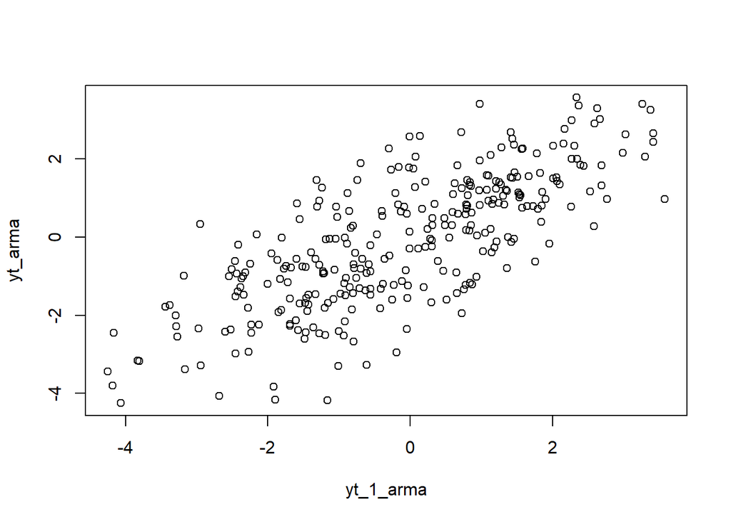

```r
plot(y=yt_arma,x=yt_1_arma)
```

Berdasarkan scatterplot tersebut, terlihat bahwa terdapat hubungan positif antara $Y_t$ dengan $Y_{t-1}$. Hal ini sesuai dengan teori yang ada

```r
cor(yt_arma,yt_1_arma)
```

```
## [1] 0.7500502
```

#### Korelasi antara $Y_t$ dengan $Y_{t-2}$

```r
#Yt
yt_arma <- arma22[-c(1,2)]
yt_arma
```

```
##   [1] -1.077217991 -1.591518838  0.857972776  0.621035121  1.370172149
##   [6] -0.007956387 -0.294459819 -0.468639788  0.064197964  1.280447276
##  [11]  2.299820151  2.331692495  3.570483281  0.975108360  1.955730067
##  [16] -0.166315069  1.795026529  0.716332295  2.684199639  1.838707447
##  [21]  0.386488842 -0.611271184 -3.272954173 -2.543542963 -1.000509445
##  [26] -2.414583612 -0.197220330 -2.951322140  0.338515524  0.850945663
##  [31]  1.301767007  1.052315350  0.109557613 -0.298376756  2.261822233
##  [36]  2.006523340  2.343710148  2.003844475  1.499738568  1.544194413
##  [41]  1.072603220  1.215097647 -0.118218819 -1.134909507 -0.046157902
##  [46] -2.350199766 -1.007307102 -3.293379577 -2.004973223 -1.197011866
##  [51] -2.508200886 -0.821371322 -1.848235549 -1.915646293 -3.826818975
##  [56] -3.166651363 -3.381488796 -1.745119860 -0.739691484  1.465071595
##  [61]  1.662114755  1.561746742  2.256486660  0.784682474  0.185865226
##  [66] -1.279230285  0.936579335  0.040043042  1.755268572 -0.627129785
##  [71] -1.359907284 -2.315126738 -0.904021314 -1.038691872  0.772934722
```

[output cut: 45 more lines]

```r
#Yt-2
yt_2_arma <- arma22[-c(299,300)]
yt_2_arma
```

```
##   [1] -0.423982089 -1.829945001 -1.077217991 -1.591518838  0.857972776
##   [6]  0.621035121  1.370172149 -0.007956387 -0.294459819 -0.468639788
##  [11]  0.064197964  1.280447276  2.299820151  2.331692495  3.570483281
##  [16]  0.975108360  1.955730067 -0.166315069  1.795026529  0.716332295
##  [21]  2.684199639  1.838707447  0.386488842 -0.611271184 -3.272954173
##  [26] -2.543542963 -1.000509445 -2.414583612 -0.197220330 -2.951322140
##  [31]  0.338515524  0.850945663  1.301767007  1.052315350  0.109557613
##  [36] -0.298376756  2.261822233  2.006523340  2.343710148  2.003844475
##  [41]  1.499738568  1.544194413  1.072603220  1.215097647 -0.118218819
##  [46] -1.134909507 -0.046157902 -2.350199766 -1.007307102 -3.293379577
##  [51] -2.004973223 -1.197011866 -2.508200886 -0.821371322 -1.848235549
##  [56] -1.915646293 -3.826818975 -3.166651363 -3.381488796 -1.745119860
##  [61] -0.739691484  1.465071595  1.662114755  1.561746742  2.256486660
##  [66]  0.784682474  0.185865226 -1.279230285  0.936579335  0.040043042
##  [71]  1.755268572 -0.627129785 -1.359907284 -2.315126738 -0.904021314
```

[output cut: 45 more lines]

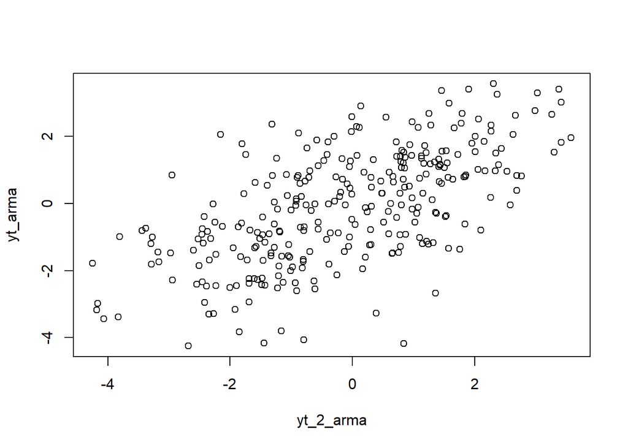

```r
plot(y=yt_arma,x=yt_2_arma)
```

```r
cor(yt_arma,yt_2_arma)
```

```
## [1] 0.6199636
```

#### Korelasi antara $Y_t$ dengan $Y_{t-3}$

```r
#Yt
yt_arma <- arma22[-c(1,2,3)]
yt_arma
```

```
##   [1] -1.591518838  0.857972776  0.621035121  1.370172149 -0.007956387
##   [6] -0.294459819 -0.468639788  0.064197964  1.280447276  2.299820151
##  [11]  2.331692495  3.570483281  0.975108360  1.955730067 -0.166315069
##  [16]  1.795026529  0.716332295  2.684199639  1.838707447  0.386488842
##  [21] -0.611271184 -3.272954173 -2.543542963 -1.000509445 -2.414583612
##  [26] -0.197220330 -2.951322140  0.338515524  0.850945663  1.301767007
##  [31]  1.052315350  0.109557613 -0.298376756  2.261822233  2.006523340
##  [36]  2.343710148  2.003844475  1.499738568  1.544194413  1.072603220
##  [41]  1.215097647 -0.118218819 -1.134909507 -0.046157902 -2.350199766
##  [46] -1.007307102 -3.293379577 -2.004973223 -1.197011866 -2.508200886
##  [51] -0.821371322 -1.848235549 -1.915646293 -3.826818975 -3.166651363
##  [56] -3.381488796 -1.745119860 -0.739691484  1.465071595  1.662114755
##  [61]  1.561746742  2.256486660  0.784682474  0.185865226 -1.279230285
##  [66]  0.936579335  0.040043042  1.755268572 -0.627129785 -1.359907284
##  [71] -2.315126738 -0.904021314 -1.038691872  0.772934722 -1.223602887
```

[output cut: 45 more lines]

```r
#Yt-3
yt_3_arma <- arma22[-c(298,299,300)]
yt_3_arma
```

```
##   [1] -0.423982089 -1.829945001 -1.077217991 -1.591518838  0.857972776
##   [6]  0.621035121  1.370172149 -0.007956387 -0.294459819 -0.468639788
##  [11]  0.064197964  1.280447276  2.299820151  2.331692495  3.570483281
##  [16]  0.975108360  1.955730067 -0.166315069  1.795026529  0.716332295
##  [21]  2.684199639  1.838707447  0.386488842 -0.611271184 -3.272954173
##  [26] -2.543542963 -1.000509445 -2.414583612 -0.197220330 -2.951322140
##  [31]  0.338515524  0.850945663  1.301767007  1.052315350  0.109557613
##  [36] -0.298376756  2.261822233  2.006523340  2.343710148  2.003844475
##  [41]  1.499738568  1.544194413  1.072603220  1.215097647 -0.118218819
##  [46] -1.134909507 -0.046157902 -2.350199766 -1.007307102 -3.293379577
##  [51] -2.004973223 -1.197011866 -2.508200886 -0.821371322 -1.848235549
##  [56] -1.915646293 -3.826818975 -3.166651363 -3.381488796 -1.745119860
##  [61] -0.739691484  1.465071595  1.662114755  1.561746742  2.256486660
##  [66]  0.784682474  0.185865226 -1.279230285  0.936579335  0.040043042
##  [71]  1.755268572 -0.627129785 -1.359907284 -2.315126738 -0.904021314
```

[output cut: 45 more lines]

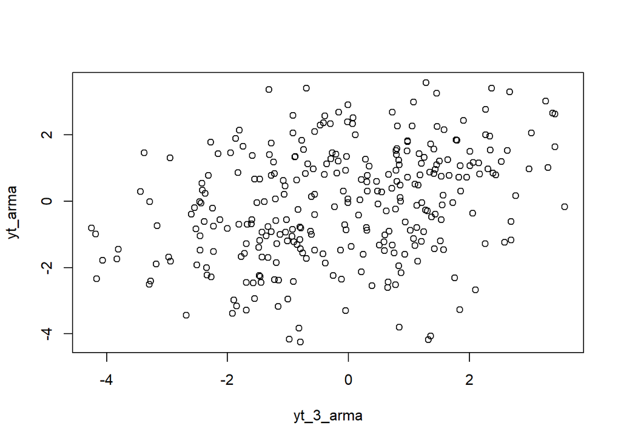

```r
plot(y=yt_arma,x=yt_3_arma)
```

```r
cor(yt_arma,yt_3_arma)
```

```
## [1] 0.326507
```